# High School Seniors t Test

```r
library(tidyverse)
library(DT)
library(pander)
library(readr)
library(mosaic)

# ../../Data/ go up two folders and into Data file
HSS <- read_csv("../../Data/HighSchoolSeniors.csv")
#Remember: select "Session, Set Working Directory, To Source File Location", and then play this R-chunk into your console to read the HSS data into R.
```

## Background

In order to keep the United States competitive in the modern world, there has been a the push for Science, Technology, Engineering, and Mathematics (STEM) subjects in schools across the United States. Many people consider STEM subjects to be more rigorous than others, but one would think that in any group of students there will be varying degrees of motivation, committment, and stress regardless of the subject. Is there a difference between the pressure over schoolwork experienced by high school aged students who prefer STEM subjects those who prefer non-STEM subjects?

Data from [U.S. Census at School](https://ww2.amstat.org/censusatschool/about.cfm), a project which surveys students across the United States and allows classrooms across the country access to the data for the purpose of studying statistics, was used to answer these questions.
$$H_0: \mu_\text{STEM} - \mu_\text{non-STEM} = 0$$

$$H_a: \mu_\text{STEM} - \mu_\text{non-STEM}\neq 0$$

The significance level will be set at
$$\alpha = 0.05$$
The data table below contains the age, gender, interest, hours of study, and level of pressure experienced. Note the data was limited to students between the years of 14 and 19, those corresponding the age-range of most high-school students.

```r
qualHSS <- HSS %>%
  select(c(Ageyears, Gender, Favorite_School_Subject, Doing_Homework_Hours, Schoolwork_Pressure, Planned_Education_Level)) %>%
  mutate(
    Interest_Category = case_when(
      Favorite_School_Subject == "Art"~"Non-STEM",
      Favorite_School_Subject == "English"~"Non-STEM",
      Favorite_School_Subject == "Languages"~"Non-STEM",
      Favorite_School_Subject == "Social Studies"~"Non-STEM",
      Favorite_School_Subject == "History"~"Non-STEM",
      Favorite_School_Subject == "Music"~"Non-STEM",
      Favorite_School_Subject == "Physical Education" ~ "Non-STEM",
      Favorite_School_Subject == "Geography"~"STEM",
      Favorite_School_Subject == "Science"~"STEM",
      Favorite_School_Subject == "Computers and technology"~"STEM",
      Favorite_School_Subject == "Mathematics and statistics" ~ "STEM",
      TRUE ~ "Other"
    )
  ) %>% filter(Interest_Category == c("Non-STEM", "STEM"), Ageyears >= 14, Ageyears <= 19) %>%
  mutate(
      Schoolwork_Pressure_num = case_when(
        Schoolwork_Pressure == "None" ~ 0,
        Schoolwork_Pressure == "Very little" ~ 1,
        Schoolwork_Pressure == "Some" ~ 2,
        Schoolwork_Pressure == "A lot" ~ 3
      )
  )
datatable(qualHSS, options=list(lengthMenu = c(5,10,30)), extensions="Responsive")
```

|  | Ageyears | Gender | Favorite_School_Subject | Doing_Homework_Hours | Schoolwork_Pressure | Planned_Education_Level | Interest_Category | Schoolwork_Pressure_num |
| --- | --- | --- | --- | --- | --- | --- | --- | --- |
| 1 | 18 | Female | Art | 2 | Some | Graduate degree | Non-STEM | 2 |
| 2 | 17 | Male | Mathematics and statistics | 3 | Very little | Graduate degree | STEM | 1 |
| 3 | 17 | Male | Science | 10 | Some | Graduate degree | STEM | 2 |
| 4 | 17 | Female | Science |  | Some | High school | STEM | 2 |
| 5 | 17 | Male | History | 2 | Very little | High school | Non-STEM | 1 |
| 6 | 17 | Male | History | 4 | Very little | Graduate degree | Non-STEM | 1 |
| 7 | 17 | Female | Science | 2 | Very little | Graduate degree | STEM | 1 |
| 8 | 17 | Female | Mathematics and statistics | 10 | Some | Graduate degree | STEM | 2 |
| 9 | 17 | Female | English | 6 | Some | Undergraduate degree | Non-STEM | 2 |
| 10 | 16 | Male | Mathematics and statistics | 10 | A lot | Graduate degree | STEM | 3 |

[output cut: 160 more lines]

## Analysis

The students in the study were given the following options for favorite school subject:

- Geography
- Science
- Computers and Technology
- Mathematics and statistics
- Art
- English
- Languages
- Social Studies
- History
- Music
- Physical Education

The first four subjects were marked as STEM subjects while the remaining subjects were marked as non-STEM subjects, resulting in 94 students prefering a STEM subject and 76 prefering non-STEM subjects.

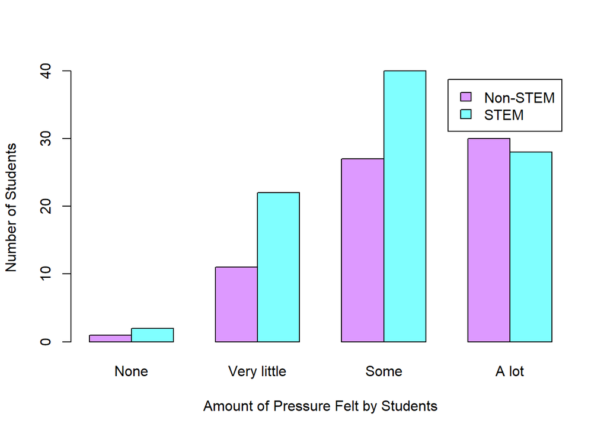

```r
qualHSS$Schoolwork_Pressure <- factor(qualHSS$Schoolwork_Pressure, levels = c("None", "Very little", "Some", "A lot"))
barplot(table(qualHSS$Interest_Category, qualHSS$Schoolwork_Pressure), beside = TRUE, col = c("#dd99ff", "#80ffff"), legend.text = TRUE, xlab="Amount of Pressure Felt by Students", ylab = "Number of Students")
```

Very few students from either group felt no pressure related to school work. More students from the STEM group felt “Some” and “Very little” pressure. While slighty more students from the non-STEM group felt “A lot” of pressure. To ascertain whether the both groups of students felt similar amounts of stress, the four answer options were given values as follows: None = 0, Very little = 1, Some = 2, A lot = 3.

The following table depicts the mean of pressure felt due to schoolwork for both students who prefer a STEM subject and those who do not. A five number summary is not useful as we only have four values.

```r
stemHSS <- filter(qualHSS, Interest_Category == "STEM")
nonstemHSS <- filter(qualHSS, Interest_Category == "Non-STEM")

# Bind vectors
quanHSSTable <- rbind('Non-STEM'=favstats(nonstemHSS$Schoolwork_Pressure_num), 'STEM'=favstats(stemHSS$Schoolwork_Pressure_num))

# Create the table


pander(quanHSSTable[c("mean")], caption="Student's Mean Level of Schoolwork Pressure Felt")
```

Student’s Mean Level of Schoolwork Pressure Felt

|  | mean |
| --- | --- |
| **Non-STEM** | 2.246 |
| **STEM** | 2.022 |

Notice the mean of the students who prefer a non-STEM subject is higher than that of STEM students. In other words, the students favoring subjects like art, music, and history felt more pressure related to schoolwork than those students who prefer subjects like math and science.

As there are more than 30 students in each group and the participants were from random classes across the country, both requirements for conducting a independent samples t-test are met.

```r
pander(t.test(qualHSS$Schoolwork_Pressure_num~qualHSS$Interest_Category, alternative = "two.sided", mu=0, conf.level=0.95), caption="Independent Samples t Test of Homework Pressure Felt by Non-STEM and STEM Students")
```

Independent Samples t Test of Homework Pressure Felt by Non-STEM and STEM Students (continued below)

| Test statistic | df | P value | Alternative hypothesis |
| --- | --- | --- | --- |
| 1.797 | 148.9 | 0.07431 | two.sided |

| mean in group Non-STEM | mean in group STEM |
| --- | --- |
| 2.246 | 2.022 |

There is insufficient evidence to reject the null hypothesis: $p = 0.07431 > \alpha$.

## Interpretation

The data shows a higher mean for schoolwork pressure felt by students who prefer non-STEM subjects than those who prefer STEM subjects. However, the p-value of the independent samples t-test indicates that the difference is not statistically significant. It is recommended that further studies be conducted with a higher range of values for the amount of schoolwork pressure felt. Having more than five values would allow a five-number summary to be completed and would allow greater precision in the results.